# Group 11 _Phase 3 Submission

# Model 3: XGBoosting

## XGBoost with default settings

```python
import xgboost as xgb
full_pipeline_with_predictor = Pipeline([
        ("preparation", data_prep_pipeline),
        ("xgboost", xgb.XGBClassifier())
    ])

start = time()
model_5 = full_pipeline_with_predictor.fit(X_train, y_train)
train_time = np.round(time() - start, 4)
```

```python
exp_name = f"XGBoost_{len(selected_features)}_features"
expLog.loc[len(expLog)] = [f"{exp_name}"] + list(np.round(
               [accuracy_score(y_train, model_5.predict(X_train)),
                accuracy_score(y_valid, model_5.predict(X_valid)),
                accuracy_score(y_test, model_5.predict(X_test)),
                roc_auc_score(y_train, model_5.predict_proba(X_train)[:, 1]),
                roc_auc_score(y_valid, model_5.predict_proba(X_valid)[:, 1]),
                roc_auc_score(y_test, model_5.predict_proba(X_test)[:, 1]),
                train_time
                ],4))

expLog
```

|  | exp_name | Train Acc | Valid Acc | Test Acc | Train AUC | Valid AUC | Test AUC | Train Time |
| --- | --- | --- | --- | --- | --- | --- | --- | --- |
| 0 | Baseline_14_features | 0.9198 | 0.9192 | 0.9159 | 0.7372 | 0.7381 | 0.7383 | 2.2682 |
| 1 | LogisticRegression_116_features | 0.9200 | 0.9200 | 0.9162 | 0.7646 | 0.7621 | 0.7634 | 9.5147 |
| 2 | LogisticRegression_GSCV_116_features | 0.9200 | 0.9200 | 0.9162 | 0.7646 | 0.7621 | 0.7634 | 346.6979 |
| 3 | RamdomForest_116_features | 0.9198 | 0.9194 | 0.9160 | 0.7507 | 0.7484 | 0.7491 | 56.4632 |
| 4 | XGBoost_116_features | 0.9287 | 0.9193 | 0.9152 | 0.8833 | 0.7733 | 0.7774 | 50.3208 |

## XGBoost with CV

```python
'''full_pipeline_with_predictor = Pipeline([
        ("preparation", data_prep_pipeline),
        ("xgboost", xgb.XGBClassifier(n_jobs= -1))
    ])

param_grid = {"xgboost__learning_rate"    : [0.05, 0.15, 0.30],
             "xgboost__max_depth"        : [3, 8, 15],
             "xgboost__gamma"            : [0.0, 0.2, 0.4]}


start = time()
model_6 = GridSearchCV(full_pipeline_with_predictor, param_grid, cv=5, n_jobs=-1)

model_6.fit(X_train,y_train)
train_time = np.round(time() - start, 4)'''
```

# Model 4: Light GBM

```python
import lightgbm as lg

params = {
    'n_estimators': 1000, 'learning_rate': 0.1, 'n_jobs': -1
}

full_pipeline_with_predictor = Pipeline([
        ("preparation", data_prep_pipeline),
        ('mdl',  lg.LGBMClassifier(**params))
    ])

start = time()
lgbm_model = full_pipeline_with_predictor.fit(X_train, y_train)
train_time = np.round(time() - start, 4)

print("LGBM accuracy score: ", np.round(accuracy_score(y_train, lgbm_model.predict(X_train)), 3))

print("LGBM roc_auc_score: ", roc_auc_score(y_train, lgbm_model.predict_proba(X_train)[:, 1]))
```

```
LGBM accuracy score:  0.943
LGBM roc_auc_score:  0.9716359001899039
```

```python
exp_name = f"LGBM_{len(selected_features)}_features"
expLog.loc[len(expLog)] = [f"{exp_name}"] + list(np.round(
               [accuracy_score(y_train, lgbm_model.predict(X_train)),
                accuracy_score(y_valid, lgbm_model.predict(X_valid)),
                accuracy_score(y_test, lgbm_model.predict(X_test)),
                roc_auc_score(y_train, lgbm_model.predict_proba(X_train)[:, 1]),
                roc_auc_score(y_valid, lgbm_model.predict_proba(X_valid)[:, 1]),
                roc_auc_score(y_test, lgbm_model.predict_proba(X_test)[:, 1]),
                train_time
                ],4))

expLog
```

|  | exp_name | Train Acc | Valid Acc | Test Acc | Train AUC | Valid AUC | Test AUC | Train Time |
| --- | --- | --- | --- | --- | --- | --- | --- | --- |
| 0 | Baseline_14_features | 0.9198 | 0.9192 | 0.9159 | 0.7372 | 0.7381 | 0.7383 | 2.2682 |
| 1 | LogisticRegression_116_features | 0.9200 | 0.9200 | 0.9162 | 0.7646 | 0.7621 | 0.7634 | 9.5147 |
| 2 | LogisticRegression_GSCV_116_features | 0.9200 | 0.9200 | 0.9162 | 0.7646 | 0.7621 | 0.7634 | 346.6979 |
| 3 | RamdomForest_116_features | 0.9198 | 0.9194 | 0.9160 | 0.7507 | 0.7484 | 0.7491 | 56.4632 |
| 4 | XGBoost_116_features | 0.9287 | 0.9193 | 0.9152 | 0.8833 | 0.7733 | 0.7774 | 50.3208 |
| 5 | LGBM_116_features | 0.9430 | 0.9193 | 0.9150 | 0.9716 | 0.7715 | 0.7757 | 19.9208 |

# Model 5: Light GBM Advanced

```python
import matplotlib.pyplot as plt
import seaborn as sns
import gc
import time
import warnings
warnings.simplefilter(action = 'ignore', category = FutureWarning)

from sklearn.metrics import roc_auc_score, precision_score, recall_score
from sklearn.model_selection import KFold, StratifiedKFold

from scipy.stats import ranksums
from bayes_opt import BayesianOptimization
```

```python
print(df_train.shape)
print(df_test.shape)
```

```
(307511, 188)
(48744, 187)
```

```python
# combine training and testing dataset into one dataframe, so we can process them at the same time.

df = pd.concat([df_train, df_test], axis = 0, ignore_index = True)
```

```python
df.shape
```

```
(356255, 188)
```

```python
# one_hot_encoder
```

```python
def one_hot_encoder(data, nan_as_category = True):
    original_columns = list(data.columns)
    categorical_columns = [col for col in data.columns \
                           if not pd.api.types.is_numeric_dtype(data[col].dtype)]
    for c in categorical_columns:
        if nan_as_category:
            data[c].fillna('NaN', inplace = True)
        values = list(data[c].unique())
        for v in values:
            data[str(c) + '_' + str(v)] = (data[c] == v).astype(np.uint8)
    data.drop(categorical_columns, axis = 1, inplace = True)
    return data, [c for c in data.columns if c not in original_columns]
```

```python
one_hot_encoder(df)
df.shape
```

```
(356255, 318)
```

```python
#Removing features not interesting for classifier

from lightgbm import LGBMClassifier

base_classifier = LGBMClassifier(random_state = 0)

def dropFeatures(data, clf):
    train_index = data[data['TARGET'].notnull()].index
    train_columns = data.drop('TARGET', axis = 1).columns

    score = 1
    new_columns = []
    while score > .7:
        train_columns = train_columns.drop(new_columns)
        clf.fit(data.loc[train_index, train_columns], data.loc[train_index, 'TARGET'])
        f_imp = pd.Series(clf.feature_importances_, index = train_columns)
        score = roc_auc_score(data.loc[train_index, 'TARGET'],
                              clf.predict_proba(data.loc[train_index, train_columns])[:, 1])
        new_columns = f_imp[f_imp > 0].index

    data.drop(train_columns, axis = 1, inplace = True)
    print('After removing features not interesting for classifier there are {0:d} features'.format(data.shape[1]))
    return data

df = dropFeatures(df, base_classifier)
```

```
After removing features not interesting for classifier there are 180 features
```

```python
def cv_scores(df, num_folds, params, stratified = False, verbose = -1,
              save_train_prediction = False, train_prediction_file_name = 'train_prediction.csv',
              save_test_prediction = True, test_prediction_file_name = 'test_prediction.csv'):
    warnings.simplefilter('ignore')

    clf = LGBMClassifier(**params)

    # Divide in training/validation and test data
    train_df = df[df['TARGET'].notnull()]
    test_df = df[df['TARGET'].isnull()]
    print("Starting LightGBM. Train shape: {}, test shape: {}".format(train_df.shape, test_df.shape))

    # Cross validation model
    if stratified:
        folds = StratifiedKFold(n_splits = num_folds, shuffle = True, random_state = 1001)
    else:
        folds = KFold(n_splits = num_folds, shuffle = True, random_state = 1001)

    # Create arrays and dataframes to store results
    train_pred = np.zeros(train_df.shape[0])
    train_pred_proba = np.zeros(train_df.shape[0])

    test_pred = np.zeros(train_df.shape[0])
    test_pred_proba = np.zeros(train_df.shape[0])

    prediction = np.zeros(test_df.shape[0])

    feats = [f for f in train_df.columns if f not in ['TARGET','SK_ID_CURR','SK_ID_BUREAU','SK_ID_PREV','index']]

    df_feature_importance = pd.DataFrame(index = feats)

    for n_fold, (train_idx, valid_idx) in enumerate(folds.split(train_df[feats], train_df['TARGET'])):
        print('Fold', n_fold, 'started at', time.ctime())
        train_x, train_y = train_df[feats].iloc[train_idx], train_df['TARGET'].iloc[train_idx]
        valid_x, valid_y = train_df[feats].iloc[valid_idx], train_df['TARGET'].iloc[valid_idx]

        clf.fit(train_x, train_y,
                eval_set = [(train_x, train_y), (valid_x, valid_y)], eval_metric = 'auc',
                verbose = verbose, early_stopping_rounds = 200)

        train_pred[train_idx] = clf.predict(train_x, num_iteration = clf.best_iteration_)
        train_pred_proba[train_idx] = clf.predict_proba(train_x, num_iteration = clf.best_iteration_)[:, 1]
        test_pred[valid_idx] = clf.predict(valid_x, num_iteration = clf.best_iteration_)
        test_pred_proba[valid_idx] = clf.predict_proba(valid_x, num_iteration = clf.best_iteration_)[:, 1]

        prediction += \
                clf.predict_proba(test_df[feats], num_iteration = clf.best_iteration_)[:, 1] / folds.n_splits

        df_feature_importance[n_fold] = pd.Series(clf.feature_importances_, index = feats)

        print('Fold %2d AUC : %.6f' % (n_fold, roc_auc_score(valid_y, test_pred_proba[valid_idx])))
        del train_x, train_y, valid_x, valid_y
        gc.collect()

    roc_auc_train = roc_auc_score(train_df['TARGET'], train_pred_proba)
    precision_train = precision_score(train_df['TARGET'], train_pred, average = None)
    recall_train = recall_score(train_df['TARGET'], train_pred, average = None)

    roc_auc_test = roc_auc_score(train_df['TARGET'], test_pred_proba)
    precision_test = precision_score(train_df['TARGET'], test_pred, average = None)
    recall_test = recall_score(train_df['TARGET'], test_pred, average = None)

    print('Full AUC score %.6f' % roc_auc_test)

    df_feature_importance.fillna(0, inplace = True)
    df_feature_importance['mean'] = df_feature_importance.mean(axis = 1)

    # Write prediction files
    if save_train_prediction:
        df_prediction = train_df[['SK_ID_CURR', 'TARGET']]
        df_prediction['Prediction'] = test_pred_proba
        df_prediction.to_csv(train_prediction_file_name, index = False)
        del df_prediction
        gc.collect()

    if save_test_prediction:
        df_prediction = test_df[['SK_ID_CURR']]
        df_prediction['TARGET'] = prediction
        df_prediction.to_csv(test_prediction_file_name, index = False)
        del df_prediction
        gc.collect()

    return df_feature_importance, \
           [roc_auc_train, roc_auc_test,
            precision_train[0], precision_test[0], precision_train[1], precision_test[1],
            recall_train[0], recall_test[0], recall_train[1], recall_test[1], 0]
```

```python
# Parameters from Tilii kernel: https://www.kaggle.com/tilii7/olivier-lightgbm-parameters-by-bayesian-opt/code
# LightGBM parameters found by Bayesian optimization

lgbm_params = {
            'nthread': 4,
            'n_estimators': 10000,
            'learning_rate': .02,
            'num_leaves': 34,
            'colsample_bytree': .9497036,
            'subsample': .8715623,
            'max_depth': 8,
            'reg_alpha': .041545473,
            'reg_lambda': .0735294,
            'min_split_gain': .0222415,
            'min_child_weight': 39.3259775,
            'silent': -1,
            'verbose': -1
}
```

```python
print("original train set shape")
print(df_train.shape)

print("original test set shape")
print(df_test.shape)

print("combined train&test after ohc abd dropped features set shape")
print(df.shape)

train_df = df[df['TARGET'].notnull()]
test_df = df[df['TARGET'].isnull()]

print("extrated train set shape")
print(train_df.shape)

print("extrated test set shape")
print(test_df.shape)
```

```
original train set shape
(307511, 188)
original test set shape
(48744, 187)
combined train&test after ohc abd dropped features set shape
(356255, 180)
extrated train set shape
(307511, 180)
extrated test set shape
(48744, 180)
```

```python
clf = LGBMClassifier(**lgbm_params)

verbose=-1
train_df = df[df['TARGET'].notnull()]
test_df = df[df['TARGET'].isnull()]

prediction = np.zeros(test_df.shape[0])
folds = KFold(n_splits = 5, shuffle = True, random_state = 1001)

# Create arrays and dataframes to store results
train_pred = np.zeros(train_df.shape[0])
train_pred_proba = np.zeros(train_df.shape[0])

test_pred = np.zeros(train_df.shape[0])
test_pred_proba = np.zeros(train_df.shape[0])
feats = [f for f in train_df.columns if f not in ['TARGET','SK_ID_CURR','SK_ID_BUREAU','SK_ID_PREV','index']]
for n_fold, (train_idx, valid_idx) in enumerate(folds.split(train_df[feats], train_df['TARGET'])):
        print('Fold', n_fold, 'started at', time.ctime())
        train_x, train_y = train_df[feats].iloc[train_idx], train_df['TARGET'].iloc[train_idx]
        valid_x, valid_y = train_df[feats].iloc[valid_idx], train_df['TARGET'].iloc[valid_idx]

        clf.fit(train_x, train_y,
                eval_set = [(train_x, train_y), (valid_x, valid_y)], eval_metric = 'auc',
                verbose = verbose, early_stopping_rounds = 200)

        train_pred[train_idx] = clf.predict(train_x, num_iteration = clf.best_iteration_)
        train_pred_proba[train_idx] = clf.predict_proba(train_x, num_iteration = clf.best_iteration_)[:, 1]
        test_pred[valid_idx] = clf.predict(valid_x, num_iteration = clf.best_iteration_)
        test_pred_proba[valid_idx] = clf.predict_proba(valid_x, num_iteration = clf.best_iteration_)[:, 1]

        prediction += \
                clf.predict_proba(test_df[feats], num_iteration = clf.best_iteration_)[:, 1] / folds.n_splits

        print('Fold %2d AUC : %.6f' % (n_fold, roc_auc_score(valid_y, test_pred_proba[valid_idx])))
        del train_x, train_y, valid_x, valid_y
        gc.collect()

df_prediction = test_df[['SK_ID_CURR']]
df_prediction['TARGET'] = prediction
```

```
Fold 0 started at Fri May  1 20:34:15 2020
Training until validation scores don't improve for 200 rounds
Early stopping, best iteration is:
[1024]	training's auc: 0.850273	training's binary_logloss: 0.212699	valid_1's auc: 0.788593	valid_1's binary_logloss: 0.240803
Fold  0 AUC : 0.788593
Fold 1 started at Fri May  1 20:35:42 2020
Training until validation scores don't improve for 200 rounds
Early stopping, best iteration is:
[1329]	training's auc: 0.861557	training's binary_logloss: 0.20852	valid_1's auc: 0.78911	valid_1's binary_logloss: 0.237521
Fold  1 AUC : 0.789110
Fold 2 started at Fri May  1 20:37:34 2020
Training until validation scores don't improve for 200 rounds
Early stopping, best iteration is:
[1508]	training's auc: 0.869955	training's binary_logloss: 0.205695	valid_1's auc: 0.78435	valid_1's binary_logloss: 0.23556
Fold  2 AUC : 0.784350
Fold 3 started at Fri May  1 20:39:42 2020
Training until validation scores don't improve for 200 rounds
Early stopping, best iteration is:
[1176]	training's auc: 0.857491	training's binary_logloss: 0.210506	valid_1's auc: 0.78593	valid_1's binary_logloss: 0.237697
Fold  3 AUC : 0.785930
Fold 4 started at Fri May  1 20:41:34 2020
Training until validation scores don't improve for 200 rounds
Early stopping, best iteration is:
[1230]	training's auc: 0.858063	training's binary_logloss: 0.210914	valid_1's auc: 0.789876	valid_1's binary_logloss: 0.233992
Fold  4 AUC : 0.789876
```

```python
# train_df = df[df['TARGET'].notnull()] to pull the original training set which means that when there is a TARGET column values, the rows has not been changed compared to the original train set
# test_df = df[df['TARGET'].isnull()] to pull the original testing set which means that when there is  no TARGET column values, the rows has not been changed compared to the original test set
# then use train_test_split on the train_df, so we did not use the test_df, which is right. We did the same train_test_split method on other models as well.

feats = [f for f in df.columns if f not in ['TARGET','SK_ID_CURR','SK_ID_BUREAU','SK_ID_PREV','index']]
X_train = df[df['TARGET'].notnull()][feats]
y_train = df[df['TARGET'].notnull()]['TARGET']


X_train, X_valid, y_train, y_valid = train_test_split(X_train, y_train, test_size=0.15,  random_state=42)
X_train, X_test, y_train, y_test = train_test_split(X_train, y_train, test_size=0.15, random_state=42)
# X_kaggle_test= df

print(f"X train           shape: {X_train.shape}")
print(f"Y train           shape: {y_train.shape}")
print()
print(f"X validation      shape: {X_valid.shape}")
print(f"Y validation      shape: {y_valid.shape}")
print()
print(f"X test            shape: {X_test.shape}")
print(f"Y test            shape: {y_test.shape}")
print()
# print(f"X X_kaggle_test   shape: {X_kaggle_test.shape}")
# print(f"Y X_kaggle_test is not available as the test dataset is from a Kaggel competition")
```

```
X train           shape: (222176, 177)
Y train           shape: (222176,)

X validation      shape: (46127, 177)
Y validation      shape: (46127,)

X test            shape: (39208, 177)
Y test            shape: (39208,)
```

```python
def display_folds_importances(feature_importance_df_, n_folds = 5):
    n_columns = 3
    n_rows = (n_folds + 1) // n_columns
    _, axes = plt.subplots(n_rows, n_columns, figsize=(8 * n_columns, 8 * n_rows))
    for i in range(n_folds):
        sns.barplot(x = i, y = 'index', data = feature_importance_df_.reset_index().sort_values(i, ascending = False).head(20),
                    ax = axes[i // n_columns, i % n_columns])
    sns.barplot(x = 'mean', y = 'index', data = feature_importance_df_.reset_index().sort_values('mean', ascending = False).head(20),
                    ax = axes[n_rows - 1, n_columns - 1])
    plt.title('LightGBM Features (avg over folds)')
    plt.tight_layout()
    plt.show()
```

```python
scores_index = [
    'roc_auc_train', 'roc_auc_test',
    'precision_train_0', 'precision_test_0',
    'precision_train_1', 'precision_test_1',
    'recall_train_0', 'recall_test_0',
    'recall_train_1', 'recall_test_1',
    'LB'
]

scores = pd.DataFrame(index = scores_index)
```

```python
feature_importance, scor = cv_scores(df, 5, lgbm_params, test_prediction_file_name = 'LGBM_submission.csv')
```

```
Starting LightGBM. Train shape: (307511, 180), test shape: (48744, 180)
Fold 0 started at Fri May  1 20:45:33 2020
Training until validation scores don't improve for 200 rounds
Early stopping, best iteration is:
[1024]	training's auc: 0.850273	training's binary_logloss: 0.212699	valid_1's auc: 0.788593	valid_1's binary_logloss: 0.240803
Fold  0 AUC : 0.788593
Fold 1 started at Fri May  1 20:47:12 2020
Training until validation scores don't improve for 200 rounds
Early stopping, best iteration is:
[1329]	training's auc: 0.861557	training's binary_logloss: 0.20852	valid_1's auc: 0.78911	valid_1's binary_logloss: 0.237521
Fold  1 AUC : 0.789110
Fold 2 started at Fri May  1 20:49:07 2020
Training until validation scores don't improve for 200 rounds
Early stopping, best iteration is:
[1508]	training's auc: 0.869955	training's binary_logloss: 0.205695	valid_1's auc: 0.78435	valid_1's binary_logloss: 0.23556
Fold  2 AUC : 0.784350
Fold 3 started at Fri May  1 20:51:41 2020
Training until validation scores don't improve for 200 rounds
Early stopping, best iteration is:
[1176]	training's auc: 0.857491	training's binary_logloss: 0.210506	valid_1's auc: 0.78593	valid_1's binary_logloss: 0.237697
Fold  3 AUC : 0.785930
Fold 4 started at Fri May  1 20:53:36 2020
Training until validation scores don't improve for 200 rounds
Early stopping, best iteration is:
[1230]	training's auc: 0.858063	training's binary_logloss: 0.210914	valid_1's auc: 0.789876	valid_1's binary_logloss: 0.233992
Fold  4 AUC : 0.789876
Full AUC score 0.787558
```

```python
step = 'Tilii`s Bayesian optimization'
scores[step] = scor
scores.loc['LB', step] = .797
scores.T
```

|  | roc_auc_train | roc_auc_test | precision_train_0 | precision_test_0 | precision_train_1 | precision_test_1 | recall_train_0 | recall_test_0 | recall_train_1 | recall_test_1 | LB |
| --- | --- | --- | --- | --- | --- | --- | --- | --- | --- | --- | --- |
| Tilii`s Bayesian optimization | 0.858036 | 0.787558 | 0.924927 | 0.922597 | 0.789971 | 0.553023 | 0.998192 | 0.9966 | 0.077422 | 0.047895 | 0.797 |

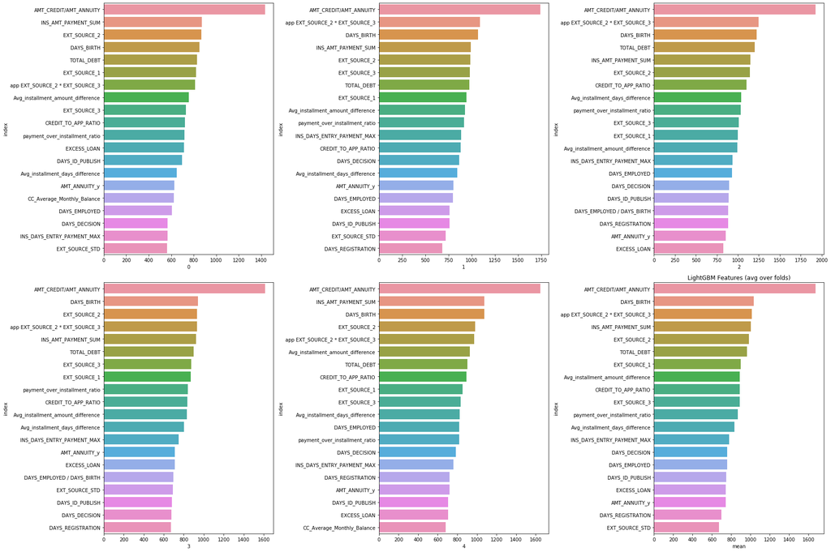

```python
display_folds_importances(feature_importance)
```

```python
feature_importance[feature_importance['mean'] == 0].shape
```

```
(3, 6)
```

```python
feature_importance.sort_values('mean', ascending = False).head(30)
```

|  | 0 | 1 | 2 | 3 | 4 | mean |
| --- | --- | --- | --- | --- | --- | --- |
| AMT_CREDIT/AMT_ANNUITY | 1437 | 1743 | 1928 | 1616 | 1649 | 1674.6 |
| DAYS_BIRTH | 853 | 1071 | 1227 | 943 | 1074 | 1033.6 |
| app EXT_SOURCE_2 * EXT_SOURCE_3 | 814 | 1091 | 1248 | 932 | 975 | 1012.0 |
| INS_AMT_PAYMENT_SUM | 871 | 990 | 1152 | 923 | 1078 | 1002.8 |
| EXT_SOURCE_2 | 867 | 988 | 1146 | 933 | 984 | 983.6 |
| TOTAL_DEBT | 829 | 975 | 1200 | 901 | 905 | 962.0 |
| EXT_SOURCE_1 | 819 | 944 | 1000 | 870 | 855 | 897.6 |
| Avg_installment_amount_difference | 755 | 929 | 997 | 831 | 927 | 887.8 |
| CREDIT_TO_APP_RATIO | 724 | 881 | 1101 | 838 | 892 | 887.2 |
| EXT_SOURCE_3 | 732 | 982 | 1011 | 876 | 834 | 887.0 |
| payment_over_installment_ratio | 719 | 919 | 1034 | 841 | 818 | 866.2 |
| Avg_installment_days_difference | 648 | 845 | 1039 | 801 | 827 | 832.0 |
| INS_DAYS_ENTRY_PAYMENT_MAX | 566 | 886 | 934 | 748 | 760 | 778.8 |
| DAYS_DECISION | 569 | 868 | 897 | 676 | 783 | 758.6 |
| DAYS_EMPLOYED | 605 | 797 | 931 | 634 | 822 | 757.8 |
| DAYS_ID_PUBLISH | 695 | 762 | 890 | 680 | 706 | 746.6 |
| EXCESS_LOAN | 712 | 764 | 825 | 712 | 705 | 743.6 |
| AMT_ANNUITY_y | 626 | 804 | 854 | 713 | 721 | 743.6 |
| DAYS_REGISTRATION | 530 | 686 | 882 | 670 | 722 | 698.0 |
| EXT_SOURCE_STD | 563 | 721 | 725 | 691 | 658 | 671.6 |
| CC_Average_Monthly_Balance | 625 | 683 | 693 | 656 | 682 | 667.8 |
| DAYS_EMPLOYED / DAYS_BIRTH | 487 | 657 | 885 | 697 | 591 | 663.4 |
| Total_Remaining_repays | 548 | 670 | 732 | 661 | 590 | 640.2 |
| AMT_CREDIT_MAX_OVERDUE | 535 | 673 | 727 | 545 | 599 | 615.8 |
| DAYS_LAST_PHONE_CHANGE | 496 | 624 | 688 | 603 | 592 | 600.6 |
| DEBT_TO_INCOME | 467 | 558 | 669 | 563 | 572 | 565.8 |
| REGION_POPULATION_RELATIVE | 423 | 659 | 606 | 539 | 508 | 547.0 |
| AMT_ANNUITY_x | 420 | 611 | 614 | 530 | 545 | 544.0 |
| Max_Initial_term | 449 | 484 | 564 | 531 | 499 | 505.4 |
| AMT_GOODS_PRICE | 474 | 472 | 600 | 424 | 483 | 490.6 |

```python
#start = time()
lgbm_advanced_model = clf.fit(X_train, y_train)
#train_time = np.round(time() - start, 4)
```

```python
print("LGBM accuracy score: ", np.round(accuracy_score(y_valid, lgbm_advanced_model.predict(X_valid)), 3))

print("LGBM roc_auc_score: ", roc_auc_score(y_valid, lgbm_advanced_model.predict_proba(X_valid)[:, 1]))
```

```
LGBM accuracy score:  0.919
LGBM roc_auc_score:  0.7678331749641282
```

```python
exp_name = f"LGBM_Advanced_{len(selected_features)}_features"
expLog.loc[len(expLog)] = [f"{exp_name}"] + list(np.round(
               [accuracy_score(y_train, lgbm_advanced_model.predict(X_train)),
                accuracy_score(y_valid, lgbm_advanced_model.predict(X_valid)),
                accuracy_score(y_test, lgbm_advanced_model.predict(X_test)),
                roc_auc_score(y_train, lgbm_advanced_model.predict_proba(X_train)[:, 1]),
                roc_auc_score(y_valid, lgbm_advanced_model.predict_proba(X_valid)[:, 1]),
                roc_auc_score(y_test, lgbm_advanced_model.predict_proba(X_test)[:, 1]),
                train_time
                ],4))

expLog
```

|  | exp_name | Train Acc | Valid Acc | Test Acc | Train AUC | Valid AUC | Test AUC | Train Time |
| --- | --- | --- | --- | --- | --- | --- | --- | --- |
| 0 | Baseline_14_features | 0.9198 | 0.9192 | 0.9159 | 0.7372 | 0.7381 | 0.7383 | 2.2682 |
| 1 | LogisticRegression_116_features | 0.9200 | 0.9200 | 0.9162 | 0.7646 | 0.7621 | 0.7634 | 9.5147 |
| 2 | LogisticRegression_GSCV_116_features | 0.9200 | 0.9200 | 0.9162 | 0.7646 | 0.7621 | 0.7634 | 346.6979 |
| 3 | RamdomForest_116_features | 0.9198 | 0.9194 | 0.9160 | 0.7507 | 0.7484 | 0.7491 | 56.4632 |
| 4 | XGBoost_116_features | 0.9287 | 0.9193 | 0.9152 | 0.8833 | 0.7733 | 0.7774 | 50.3208 |
| 5 | LGBM_116_features | 0.9430 | 0.9193 | 0.9150 | 0.9716 | 0.7715 | 0.7757 | 19.9208 |
| 6 | LGBM_Advanced_116_features | 0.9589 | 0.9191 | 0.9160 | 0.9907 | 0.7678 | 0.7779 | 19.9208 |

# Deep Learning Model

```python
def create_model():
    md2 = Sequential()

    sha = 246

    md2.add(Dense(sha, input_dim=sha, kernel_initializer="uniform"))
    md2.add(BatchNormalization())
    md2.add(Activation('relu'))
    md2.add(Dropout(0.2))

    md2.add(Dense(200, kernel_initializer="uniform"))
    md2.add(BatchNormalization())
    md2.add(Activation('relu'))
    md2.add(Dropout(0.2))

    md2.add(Dense(100, kernel_initializer="uniform"))
    md2.add(BatchNormalization())
    md2.add(Activation('relu'))
    md2.add(Dropout(0.2))

    md2.add(Dense(100, kernel_initializer="uniform"))
    md2.add(BatchNormalization())
    md2.add(Activation('relu'))
    md2.add(Dropout(0.2))


    md2.add(Dense(1,  kernel_initializer="uniform"))
    md2.add(BatchNormalization())
    md2.add(Activation('sigmoid'))

    md2.compile(loss='binary_crossentropy', optimizer='adagrad', metrics=['accuracy'])
    return md2

md3 =KerasClassifier(build_fn=create_model, epochs=30, batch_size=10, verbose=0)
```

```python
full_pipeline_with_predictor = Pipeline([
        ("preparation", data_prep_pipeline),
        ('mdl',  md3)
    ])

#start = time()
deep_learning = full_pipeline_with_predictor.fit(X_train, y_train)
#train_time = np.round(time() - start, 4)
```

```python
exp_name = f"Deep_Learning_{len(selected_features)}_features"
expLog.loc[len(expLog)] = [f"{exp_name}"] + list(np.round(
               [accuracy_score(y_train, deep_learning.predict(X_train)),
                accuracy_score(y_valid, deep_learning.predict(X_valid)),
                accuracy_score(y_test, deep_learning.predict(X_test)),
                roc_auc_score(y_train, deep_learning.predict_proba(X_train)[:, 1]),
                roc_auc_score(y_valid, deep_learning.predict_proba(X_valid)[:, 1]),
                roc_auc_score(y_test, deep_learning.predict_proba(X_test)[:, 1]),
                train_time
                ],4))

expLog
```

|  | exp_name | Train Acc | Valid Acc | Test Acc | Train AUC | Valid AUC | Test AUC | Train Time |
| --- | --- | --- | --- | --- | --- | --- | --- | --- |
| 0 | Baseline_14_features | 0.9198 | 0.9192 | 0.9159 | 0.7372 | 0.7381 | 0.7383 | 2.2682 |
| 1 | LogisticRegression_116_features | 0.9200 | 0.9200 | 0.9162 | 0.7646 | 0.7621 | 0.7634 | 9.5147 |
| 2 | LogisticRegression_GSCV_116_features | 0.9200 | 0.9200 | 0.9162 | 0.7646 | 0.7621 | 0.7634 | 346.6979 |
| 3 | RamdomForest_116_features | 0.9198 | 0.9194 | 0.9160 | 0.7507 | 0.7484 | 0.7491 | 56.4632 |
| 4 | XGBoost_116_features | 0.9287 | 0.9193 | 0.9152 | 0.8833 | 0.7733 | 0.7774 | 50.3208 |
| 5 | LGBM_116_features | 0.9430 | 0.9193 | 0.9150 | 0.9716 | 0.7715 | 0.7757 | 19.9208 |
| 6 | LGBM_Advanced_116_features | 0.9589 | 0.9191 | 0.9160 | 0.9907 | 0.7678 | 0.7779 | 19.9208 |
| 7 | Deep_Learning_116_features | 0.9201 | 0.9197 | 0.9160 | 0.8207 | 0.7677 | 0.7712 | 19.9208 |

# Evaluation metrics

## Submission File Prep

For each SK_ID_CURR in the test set, you must predict a probability for the TARGET variable. The file should contain a header and have the following format:

```
SK_ID_CURR,TARGET
100001,0.1
100005,0.9
100013,0.2
etc.
```

```python
X_kaggle_test
```

```python
test_class_scores = deep_learning.predict_proba(X_kaggle_test)[:, 1]
```

```python
test_class_scores[0:10]
```

```
array([0.03752783, 0.07479542, 0.02693677, 0.0637235 , 0.06897104,
       0.04633594, 0.02531347, 0.03487444, 0.02181976, 0.10121293],
      dtype=float32)
```

```python
#Submission dataframe
submit_df = datasets["application_test"][['SK_ID_CURR']]
submit_df['TARGET'] = test_class_scores

submit_df.head()
```

|  | SK_ID_CURR | TARGET |
| --- | --- | --- |
| 0 | 100001 | 0.037528 |
| 1 | 100005 | 0.074795 |
| 2 | 100013 | 0.026937 |
| 3 | 100028 | 0.063724 |
| 4 | 100038 | 0.068971 |

```python
submit_df.shape
```

```
(48744, 2)
```

```python
submit_df.to_csv("deep_learning.csv",index=False)
# test_prediction_file_name = 'LGBM_submission.csv'
```

# Kaggle Submission

[figure not shown]

# Write-up

## Abstract

Almost everyone, at some point in their life, will need to take out a loan, whether that be for a house, a car, or in an emergency. Unfortunately, for many people that don’t have an established credit history or bank accounts, getting approved for a loan can be a difficult task because the loan company doesn’t have many traditional metrics on which to base an underwriting decision. The goal of this project is to use alternative data to help aid in predicting whether or not an applicant is likely to repay the loan and thus get approved when they wouldn't otherwise. To tackle this problem our team will utilize the data provided by Home Credit, which consists of various demographic information about the applicant and the area in which they live, as well as data from previous Home Credit loans and loans that were reported to different credit bureaus.

## Introduction

We experimented with various classification algorithms in order to determine which produces the most accurate predictions. We have the following 8 models implemented: Baseline Logistic Regression, Logistic Regression with defaults, Logistic Regression with GridSearch, Random Forest with defaults, XGBoot, Deep Learning, LightGBM, and LightGBM with KFolds. We hope to produce a model that will allow Home Credit to successfully predict the likelihood of repayment so that more people can have access to much needed loans.

## Feature Engineering and transformers

We did feature engineering for the application train datasets and the 6 additional datasets.

- After we did feature engineering for the application train datasets and the 6 additional datasets, we came up 186 features for the merged training dataset. We selected top 100 highly correlated numerical features and 16 categorical features.
- In total we have 116 features before one hot coding for the categorical features.
- After one hot coding for the categorical features, we have 318 features in total.

## Pipelines

     ```
     num_pipeline =Pipeline([
          ('selector', DataFrameSelector(num_attribs)),
          ('imputer', SimpleImputer(strategy="median")),
          ('std_scaler', StandardScaler()),
      ])
     ```

     ```
     cat_pipeline = Pipeline([
          ('selector', DataFrameSelector(cat_attribs)),
          ('imputer', SimpleImputer(strategy='most_frequent')),
          ('ohe', OneHotEncoder(sparse=False, handle_unknown="ignore"))
      ])
     ```

3. Union numeric pipeline and categorical pipeline:
   - The codes will looks like as follows:

     ```
     full_pipeline = FeatureUnion(transformer_list=[
          ("num_pipeline", num_pipeline),
          ("cat_pipeline", cat_pipeline),
      ])
     ```

4. Use full pipeline above to build full pipeline with our desired algorithm stated above:
   - The codes will looks like as follows:

     ```
     full_pipeline = FeatureUnion(transformer_list=[
          ("num_pipeline", num_pipeline),
          ("cat_pipeline", cat_pipeline) ])
     ```

5. Our final pipeline will use full pipeline above to build full pipeline with predictor :
   - The codes will looks like as follows:

     ```
     full_pipeline_with_predictor = Pipeline([
          ("preparation", full_pipeline),
          ("linear", LogisticRegression()) # or any algorithms we selected
      ])
     ```

## Experimental Results

```python
expLog
```

[output not shown]

## Deep Learning model

Due to time constraints we were not able to spend a lot of time exploring with a deep learning model. However we were still able to take the example model provided and modify it such that it would work with our code. After training the model we were able to achieve a public score of 0.72209.

### Kaggle Submission for Deep Learning

[figure not shown]

All code can be found above in section 13.

## Conclusion

On the Phase 3, we continued on focusing Hyper parameter tuning on LightGBM model and additional featuring engineering. We analyzed our application train dataset and each additional datasets again and again. We were able to came up 71 new features to our merged datasets. We also implemented LightGBM with KFolds and the best parameters. We are happy to see our model improved and the test AUC score has been kept increasing from 0.74 to 0.78.